# 2019 Bay Wheels Ride Data Exploration

## by Odira Dancan

## Preliminary Wrangling

In this analysis, I wanted to look at the attributes that affect bike usage and thus could be used in making marketing decisions such as which customer demography to target.The main focus attributes are duration, age, weekday, user_type, bike_share_all_trips, member gender as they show specific user demographic.

## Dataset Overview

The data consisted of attributes of approximately 183412 observations in 16 variables. The key attributes included duration_sec, member_birth_year, user_type, bike_share_all_trips, and additional attributes I craeted from the dataset including, age, duration_min, day. Only important variables were considered and the unnecessary ones dropped.

## Visual Analysis of the Dataset

### plot 1a: Which user type reports the highest bike usage?

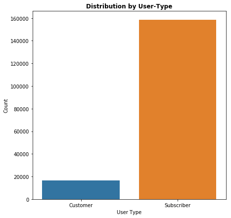

### Observations:

- Subscribers account for more than the casual customers. There is a big differnce in the number of customers and the subscribers

### plot 1b: Which gender uses the bike mostly?

```
Text(0.5,0,'User Types')
```

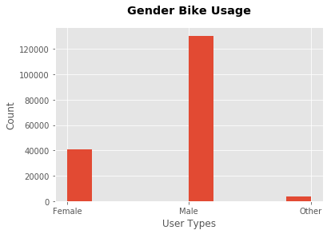

#### Observations

- males recorded the highest number of users followed by females then the other gender

### plot 2d: How does the user types compare in ride duration?

```
Text(0.5,0,'User Type')
```

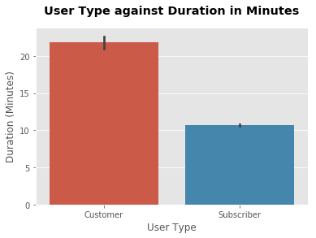

### plot 2f: which gender uses the bike frequently?

```
Text(0.5,0,'Member Gender')
```

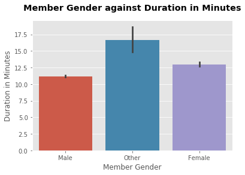

### Observtion

- The 'Other' gender recorded longest duration compared to female and male while males recorded the least duration

### plot 2i: Which user uses the bike mostly and on which day?

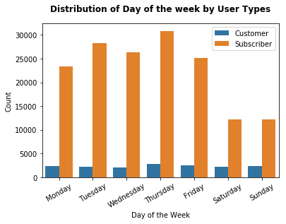

### Observation:

- Subscribers recorded the highest usage across the week compared to non-subscribers.
- Weekdays recorded highest number of bike usage compared to weekends(Saturday, Sunday)
- Thursdays and Tuesdays recorded the highest number of users while Saturday, Sunday recorded the least

### plot 2j: Which gender uses the bikes most during the week?

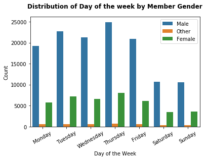

### Observation:

- There are more males than females and other gender using bikes across the week.
- The other records the least bike usage across the week followed by the females.
- Bike usage is generally high during the weekdays than weekends.

### plot 3c: Which age of users were more inclined to offering bike share for all trips?

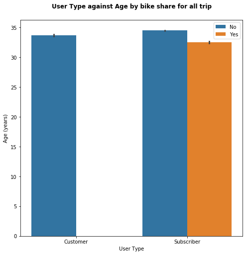

### plot 3d: Which user by gender recorded highest usage duration?

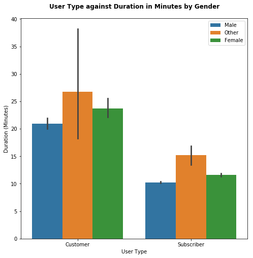

### Observation:

- Other gender customers and subscribers recorded the highest duration usage while males recorded the least.
- Generally, customers recorded longer duration more than the subscribers across all genders.